# CASE 2 - Aanaesthetics

Liam Phan, Michael Bigler, Tania Loureiro, William Elkiess, Dakota Cuellar and Ilyana El Mendili

2023-03-10

[figure not shown]

# Client Case

> A study was carried out at a hospital to compare the effects of four different types of anaesthetic as used in major operations.

> 80 patients undergoing a variety of operations were randomly assigned to one of the four anaesthetics and a variety of observations were taken on each patient both before and after the operation.
> 1. The client is interested on just one of the measurements made, namely the time, in minutes, from the reversal of the anaesthetic until the patient opened the eyes.
> 2. The client would like to know if there is any evidence of differences between the effects of the four anaesthetics?

# Definitions

> **Anaesthesia means “loss of sensation”. Medicines that cause anaesthesia are called anaesthetics.**

> Anaesthetics are used during tests and surgical operations to numb sensation in certain areas of the body or induce sleep.

> This prevents pain and discomfort, and enables a wide range of medical procedures to be carried out.

> Local anaesthetics and general anaesthetics are 2 commonly used types of anaesthetics:
> - [local anaesthesia](https://www.nhs.uk/conditions/local-anaesthesia/) is where a small area of the body is numbed and you remain fully conscious – often used during minor procedures
> - [general anaesthesia](https://www.nhs.uk/conditions/general-anaesthesia/) is where you’re totally unconscious and unaware of the procedure – often used for more serious operations

# Dataset

```r
Aanaesthetics <- fread("Aanaesthetics.txt")
Aanaesthetics <- as_data_frame(Aanaesthetics)

Aanaesthetics_Pivoted <- Aanaesthetics %>%
  pivot_longer(
    cols = c("A","B","C","D"),
    names_to = "Anaesthetic",
    values_to = "Time")

Aanaesthetics_Pivoted$Patient <- seq(1,length(Aanaesthetics_Pivoted$Anaesthetic))

col_order <- c("Patient", "Time", "Anaesthetic")
Aanaesthetics_Pivoted <- Aanaesthetics_Pivoted[, col_order]

datatable(Aanaesthetics)
```

|  | A | B | C | D |
| --- | --- | --- | --- | --- |
| 1 | 3 | 6 | 3 | 4 |
| 2 | 2 | 4 | 5 | 8 |
| 3 | 1 | 1 | 2 | 2 |
| 4 | 4 | 1 | 4 | 3 |
| 5 | 3 | 6 | 2 | 2 |
| 6 | 2 | 2 | 1 | 3 |
| 7 | 10 | 1 | 6 | 6 |
| 8 | 12 | 10 | 13 | 2 |
| 9 | 12 | 1 | 1 | 3 |
| 10 | 3 | 1 | 1 | 4 |

[output cut: 10 more lines]

# Dataset Pivoted

```r
datatable(Aanaesthetics_Pivoted)
```

|  | Patient | Time | Anaesthetic |
| --- | --- | --- | --- |
| 1 | 1 | 3 | A |
| 2 | 2 | 6 | B |
| 3 | 3 | 3 | C |
| 4 | 4 | 4 | D |
| 5 | 5 | 2 | A |
| 6 | 6 | 4 | B |
| 7 | 7 | 5 | C |
| 8 | 8 | 8 | D |
| 9 | 9 | 1 | A |
| 10 | 10 | 1 | B |

[output cut: 70 more lines]

# Analysis

## 1. Data Exploratory Analysis

### Outliers

```r
Outliers <- Aanaesthetics_Pivoted[Aanaesthetics_Pivoted$Patient %in% c(41,30,31),]

datatable(Outliers, caption = "Outliers")
```

|  | Patient | Time | Anaesthetic |
| --- | --- | --- | --- |
| 1 | 30 | 10 | B |
| 2 | 31 | 13 | C |
| 3 | 41 | 19 | A |

### Weird Patients

```r
Weird_Patient <- Aanaesthetics_Pivoted[Aanaesthetics_Pivoted$Time == 0,]

datatable(Weird_Patient, caption = "Weird Patients")
```

|  | Patient | Time | Anaesthetic |
| --- | --- | --- | --- |
| 1 | 60 | 0 | D |
| 2 | 79 | 0 | C |

> Weird Patient having 0 minute recorded in the process… Need to talk about Data Collecting Phase !

### Boxplots

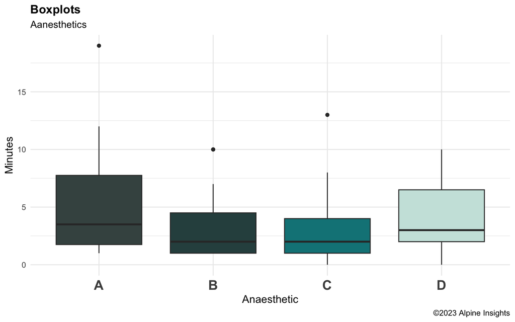

```r
Boxplot <- ggplot(Aanaesthetics_Pivoted) +
 aes(x = Anaesthetic, y = Time, fill=Anaesthetic) +
 geom_boxplot() + scale_fill_manual(values=c("#435250", "#2F4F4E", "#0D8387", "#CBE4DE")) + labs(title = "Boxplots", subtitle = "Aanesthetics", caption = "©2023 Alpine Insights", y="Minutes") +  theme_minimal() + theme(plot.title = element_text(face = "bold")) + theme(legend.position = "none") + theme(axis.text.x=element_text(size=15,face = "bold")) + theme(axis.title = element_text(size =12))

Boxplot
```

### Histograms

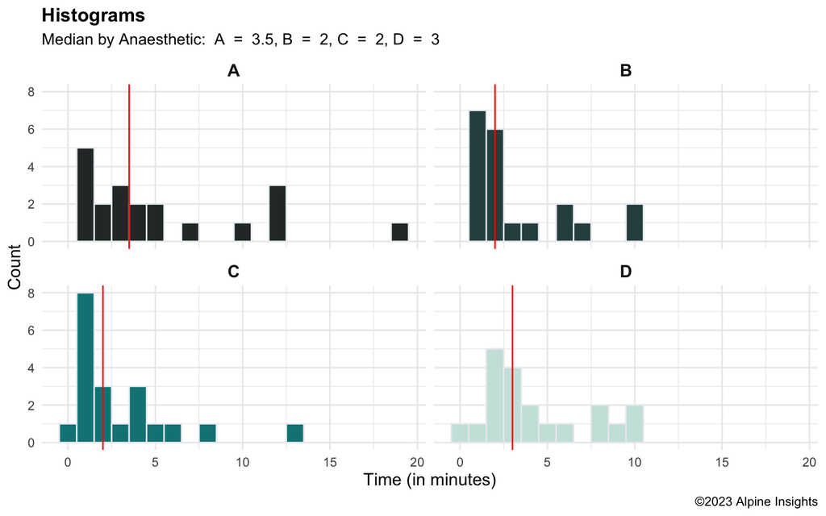

```r
med <- Aanaesthetics_Pivoted %>% group_by(Anaesthetic) %>% summarise(median = median(Time))


Histograms <- Aanaesthetics_Pivoted %>% ggplot( aes(x=Time, fill=Anaesthetic)) +
  geom_histogram( color="#e9ecef", alpha=1, position = 'identity', binwidth = 1) +
  scale_fill_manual(values=c("#2B3433", "#2F4F4E", "#0D8387", "#CBE4DE")) +
  theme_minimal() +
  labs(fill="") +
  facet_wrap(~Anaesthetic) +
  theme(plot.title = element_text(face = "bold")) +
  labs(title = "Histograms", subtitle = "Aanesthetics", caption = "©2023 Alpine Insights", y="Count") +
  theme(legend.position = "none") +
  theme(axis.title = element_text(size =12)) +
  theme(strip.text.x = element_text(size = 12,face = "bold")) +
  geom_vline(data = med, aes(xintercept = median, color = Anaesthetic), lwd = 0.5) +
  scale_color_manual(values=c("red", "red", "red", "red")) +
  labs(color = "Anaesthetic", subtitle = paste("Median by Anaesthetic: ", paste(paste(med$Anaesthetic, " = ", med$median), collapse = ", "))) +
  xlab("Time (in minutes)") +
  ylab("Count")

Histograms
```

## 2. Core Analysis

### Anova Test

```r
ANOVA <- aov(Time ~ Anaesthetic, data = Aanaesthetics_Pivoted)

ANOVA_Summary <- summary(ANOVA)

ANOVA_Summary
```

```
FALSE             Df Sum Sq Mean Sq F value Pr(>F)
FALSE Anaesthetic  3   70.9   23.65   1.776  0.159
FALSE Residuals   76 1012.0   13.32
```

> P-Value Over 5% and 10%, We cannot reject Null Hypothesis, then they are all the same

### Check Assumptions

#### Plots

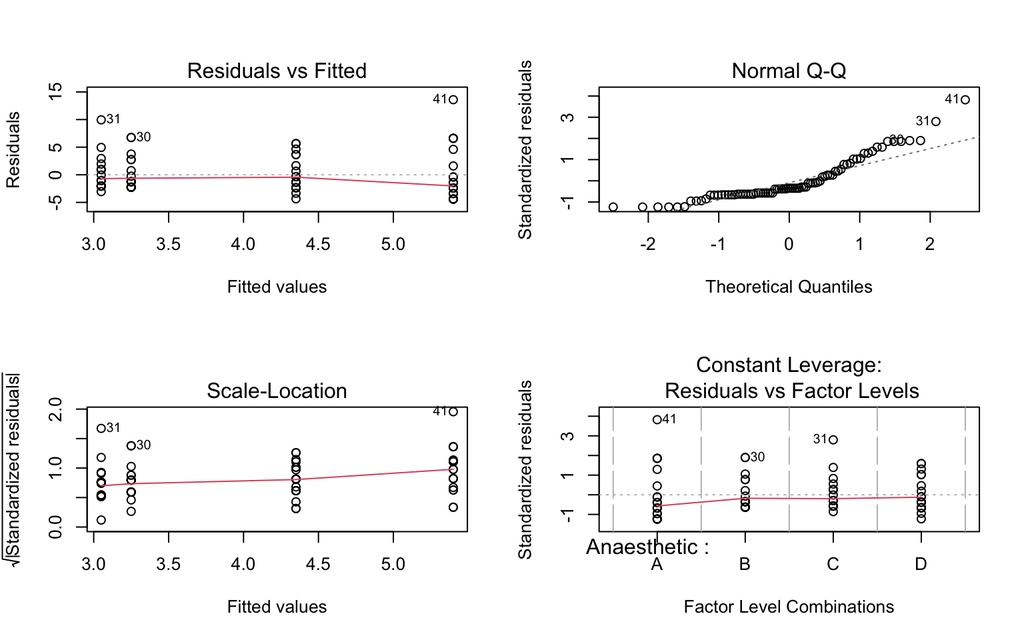

```r
# Plot ANOVA Residuals
par(mfrow=c(2,2))
plot(ANOVA)
```

```r
par(mfrow=c(1,1))

# Extract the residuals
ANOVA_Residuals <- residuals(object = ANOVA )
```

> Residuals not very good. Need to check Normality and Homogeneity (All populations variances are equal).

#### Levene Test For Homogeneity

> “Levene’s test is an alternative to Bartlett’s test when the data is not normally distributed. So, we consider the null and alternate hypotheses.
> - The Null hypothesis is variances across all samples are equal.
> - The alternative hypothesis is at least one sample has a different variance.
> - We will test the null hypothesis at 0.05 significance level i.e 95% percentile.”

[Levene’s Test in R Programming](https://www.geeksforgeeks.org/levenes-test-in-r-programming/)

```r
leveneTest(Time ~ Anaesthetic, data = Aanaesthetics_Pivoted)
```

```
FALSE Levene's Test for Homogeneity of Variance (center = median)
FALSE       Df F value Pr(>F)
FALSE group  3   1.366 0.2596
FALSE       76
```

> We cannot reject at 0.05, thus variance across all samples are equals (Homogeneity met).

#### Normality Plot

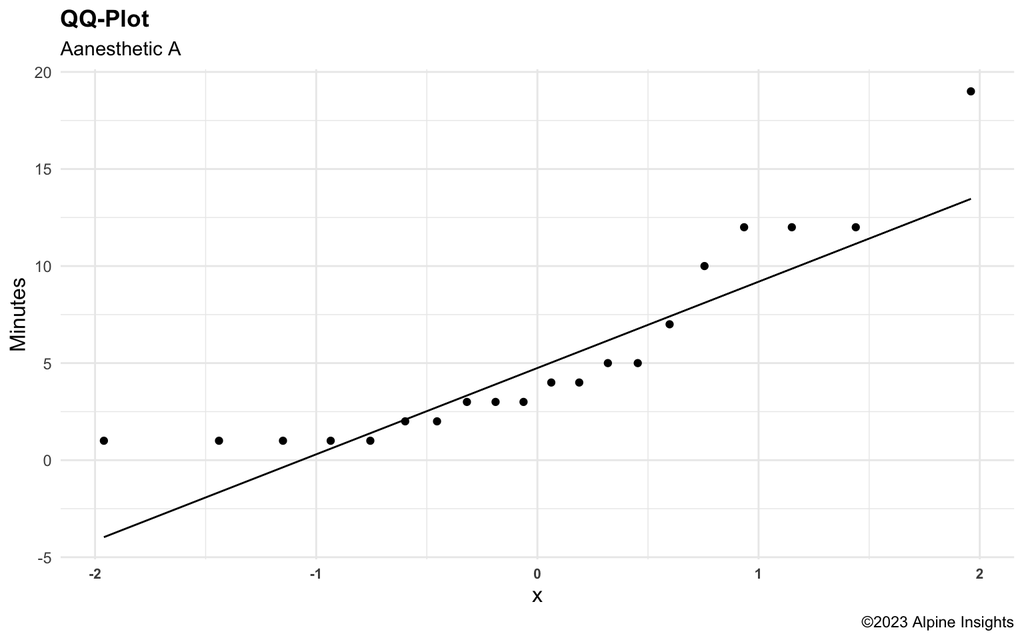

```r
GroupA <- Aanaesthetics_Pivoted[Aanaesthetics_Pivoted$Anaesthetic == "A",]
A <- ggplot(GroupA, aes(sample = Time))
A + stat_qq() + stat_qq_line() + labs(title = "QQ-Plot", subtitle = "Aanesthetic A", caption = "©2023 Alpine Insights", y="Minutes") +  theme_minimal() + theme(plot.title = element_text(face = "bold")) + theme(legend.position = "none") + theme(axis.text.x=element_text(size=8,face = "bold")) + theme(axis.title = element_text(size =12))
```

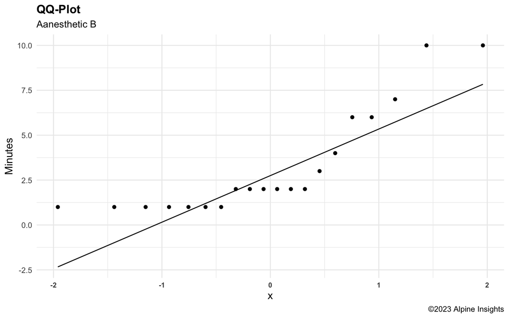

```r
GroupB <- Aanaesthetics_Pivoted[Aanaesthetics_Pivoted$Anaesthetic == "B",]
B <- ggplot(GroupB, aes(sample = Time))
B + stat_qq() + stat_qq_line() + labs(title = "QQ-Plot", subtitle = "Aanesthetic B", caption = "©2023 Alpine Insights", y="Minutes") +  theme_minimal() + theme(plot.title = element_text(face = "bold")) + theme(legend.position = "none") + theme(axis.text.x=element_text(size=8,face = "bold")) + theme(axis.title = element_text(size =12))
```

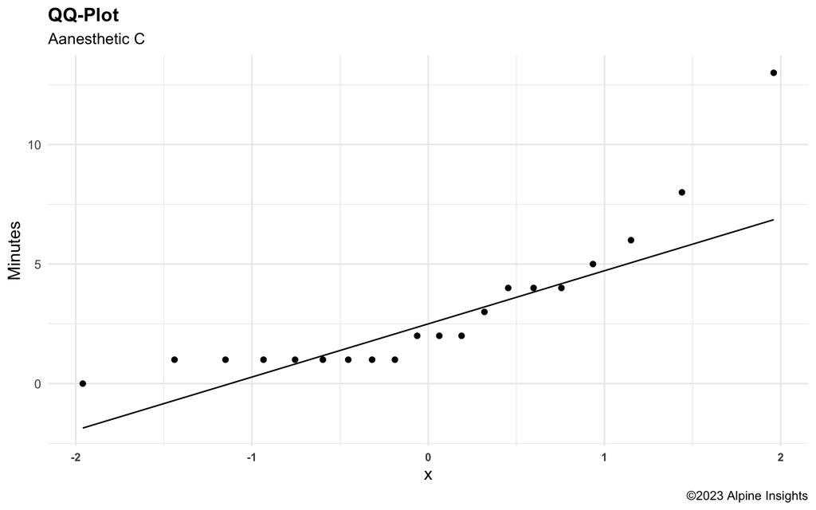

```r
GroupC <- Aanaesthetics_Pivoted[Aanaesthetics_Pivoted$Anaesthetic == "C",]
C <- ggplot(GroupC, aes(sample = Time))
C + stat_qq() + stat_qq_line() + labs(title = "QQ-Plot", subtitle = "Aanesthetic C", caption = "©2023 Alpine Insights", y="Minutes") +  theme_minimal() + theme(plot.title = element_text(face = "bold")) + theme(legend.position = "none") + theme(axis.text.x=element_text(size=8,face = "bold")) + theme(axis.title = element_text(size =12))
```

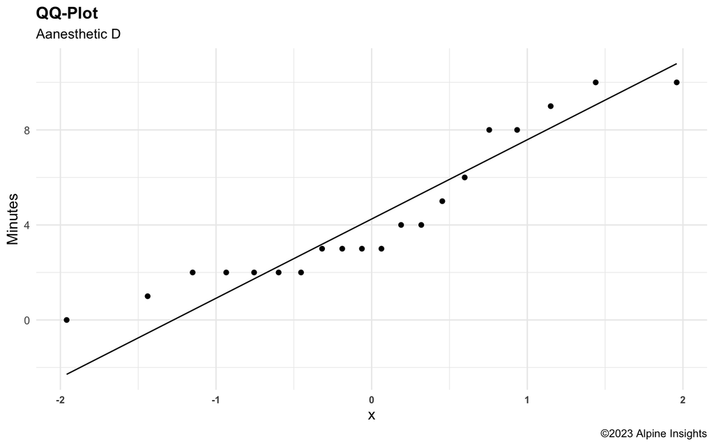

```r
GroupD <- Aanaesthetics_Pivoted[Aanaesthetics_Pivoted$Anaesthetic == "D",]
D <- ggplot(GroupD, aes(sample = Time))
D + stat_qq() + stat_qq_line() + labs(title = "QQ-Plot", subtitle = "Aanesthetic D", caption = "©2023 Alpine Insights", y="Minutes") +  theme_minimal() + theme(plot.title = element_text(face = "bold")) + theme(legend.position = "none") + theme(axis.text.x=element_text(size=8,face = "bold")) + theme(axis.title = element_text(size =12))
```

#### Shapiro-Wilk Test For Normality

> “The Shapiro-Wilk's test or Shapiro test is a normality test in frequentist statistics. The null hypothesis of Shapiro's test is that the population is distributed normally. It is among the three tests for normality designed for detecting all kinds of departure from normality. If the value of p is equal to or less than 0.05, then the hypothesis of normality will be rejected by the Shapiro test. On failing, the test can state that the data will not fit the distribution normally with 95% confidence.”

[Shapiro–Wilk Test in R Programming](https://www.geeksforgeeks.org/shapiro-wilk-test-in-r-programming/)

```r
shapiro.test(x = ANOVA_Residuals)
```

```
FALSE
FALSE   Shapiro-Wilk normality test
FALSE
FALSE data:  ANOVA_Residuals
FALSE W = 0.85738, p-value = 0.0000002888
```

> We can reject at 0.05, thus the normality is not met.

### Distributions of Groups

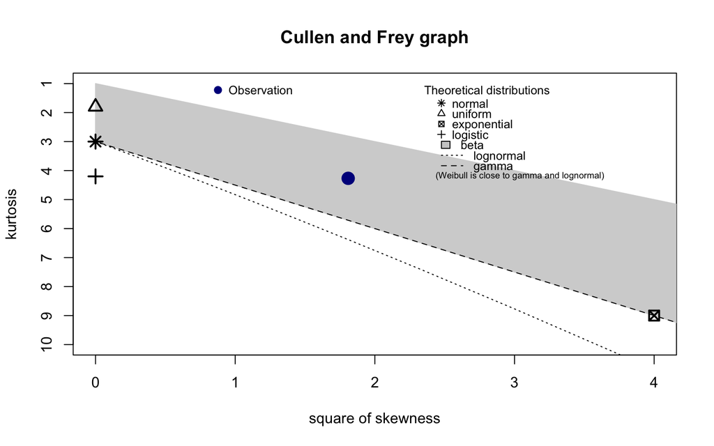

```
FALSE summary statistics
FALSE ------
FALSE min:  1   max:  19
FALSE median:  3.5
FALSE mean:  5.4
FALSE estimated sd:  5.030434
FALSE estimated skewness:  1.345002
FALSE estimated kurtosis:  4.267166
```

```r
descdist(Aanaesthetics$A, discrete = FALSE)
```

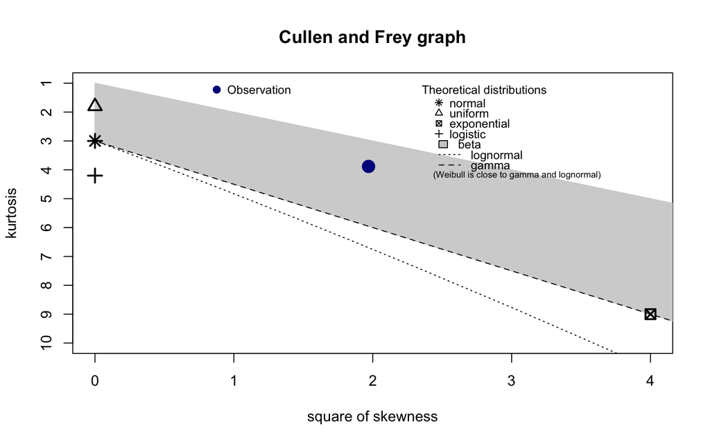

```
FALSE summary statistics
FALSE ------
FALSE min:  1   max:  10
FALSE median:  2
FALSE mean:  3.25
FALSE estimated sd:  2.953588
FALSE estimated skewness:  1.403479
FALSE estimated kurtosis:  3.882698
```

```r
descdist(Aanaesthetics$B, discrete = FALSE)
```

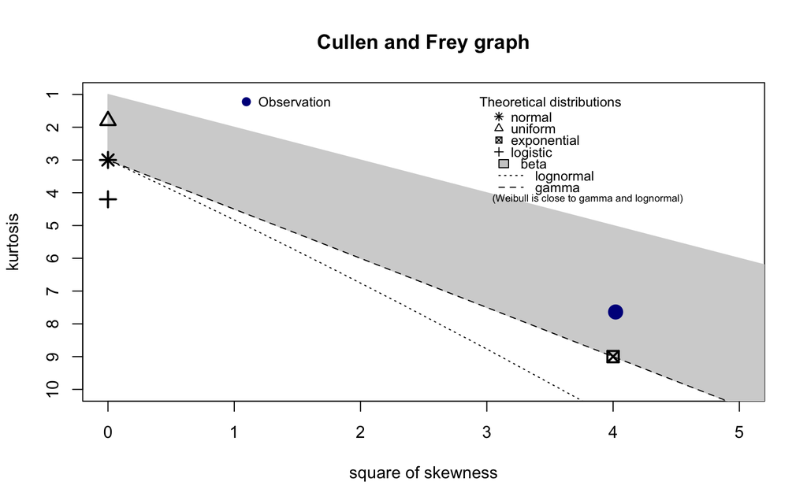

```
FALSE summary statistics
FALSE ------
FALSE min:  0   max:  13
FALSE median:  2
FALSE mean:  3.05
FALSE estimated sd:  3.11997
FALSE estimated skewness:  2.004979
FALSE estimated kurtosis:  7.638077
```

```r
descdist(Aanaesthetics$C, discrete = FALSE)
```

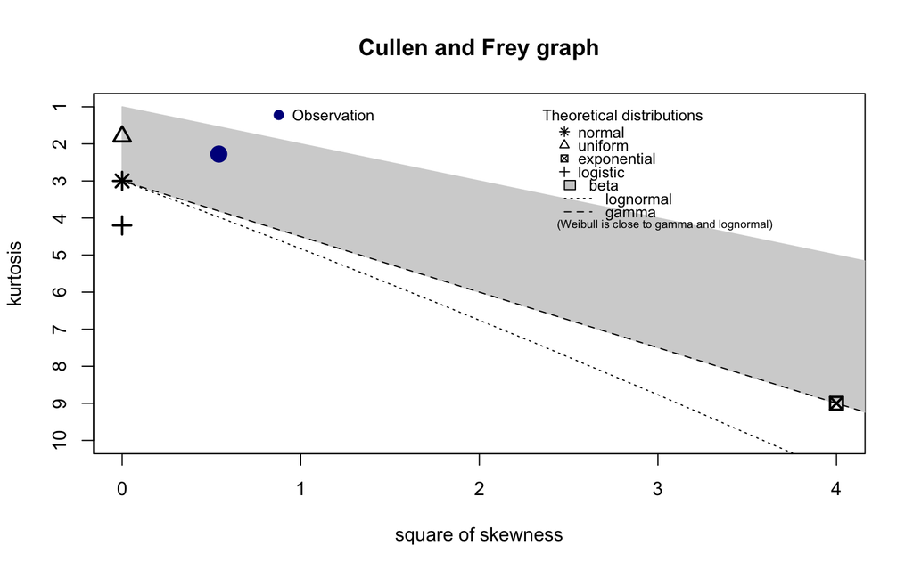

```
FALSE summary statistics
FALSE ------
FALSE min:  0   max:  10
FALSE median:  3
FALSE mean:  4.35
FALSE estimated sd:  3.082634
FALSE estimated skewness:  0.7357871
FALSE estimated kurtosis:  2.275165
```

```r
descdist(Aanaesthetics$D, discrete = FALSE)
```

> We can see that all Anaesthetic groups are beta distributed, thus the Shapiro–Wilk Test being rejected.

> We can deal with the Assumptions for ANOVA not being met with a Non-Parametric Test, Kruskal-Wallis Test giving the same answer to ANOVA.

### Kurskal-Wallis Test

```r
# Kruskal-Wallis rank sum test, which can be used when ANNOVA assumptions are not met
kruskal.test(Time ~ Anaesthetic, data = Aanaesthetics_Pivoted)
```

```
FALSE
FALSE   Kruskal-Wallis rank sum test
FALSE
FALSE data:  Time by Anaesthetic
FALSE Kruskal-Wallis chi-squared = 5.4704, df = 3, p-value = 0.1404
```

> We cannot reject Kruskal-Wallis Rank Sum Test, thus there is no differences in groups mean.

References

[One-Way ANOVA Test in R](http://www.sthda.com/english/wiki/one-way-anova-test-in-r)

[Anaesthesia](https://www.nhs.uk/conditions/anaesthesia/)

[Shapiro–Wilk Test in R Programming](https://www.geeksforgeeks.org/shapiro-wilk-test-in-r-programming/)

[Levene’s Test in R Programming](https://www.geeksforgeeks.org/levenes-test-in-r-programming/)